# Global Change and You

## Human activity has altered >70% of land surface

**Removing habitats simplifies diversity. Fewer species = lower ecosystem functions**

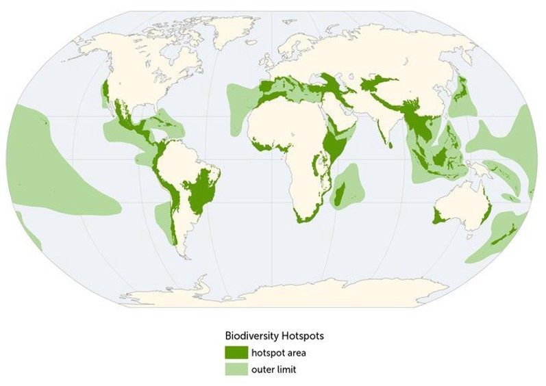

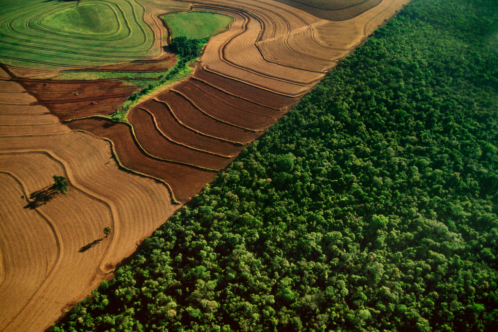

## Things to know (#s)

- **#Biodiversity Types**
- **#Biodiversity Threats**
- **#Conservation Types**
- **#Global Change Basics**

## The Big Picture: Earth’s systems and humans interact

- **Biodiversity can be measured at many scales**
  - maintaining high biodiversity has huge benefits
- **Conservation biology focuses on the population level**
  - small populations have genetic problems
- **Global Change is occurring at unprecedented rates**
  - Yes, change has occurred over Earth’s history
  - No, it has never occurred this quickly
- **Are we in a new mass extinction?**

[figure not shown]

## What is Biodiversity?

- **Level 1: Genetic Diversity**
  - within and among populations
  - *loss of alleles reduces adaptive potential*
- **Level 2: Species Diversity**
  - number of species in a system
  - local or whole extinctions possible
  - *each species has a ‘role’ in the community*
- **Level 3: Ecosystem Diversity**
  - variety of ecosystems on Earth
  - *provide services to humans*

[figure not shown]

## How do we measure biodiversity?

- **Genetic Diversity: alleles in populations**
  - what happens when populations decline/disappear?
- **Species Diversity**
  - how many species (*species richness*)?
  - how *even* are the species?
  - roles that each species play in the community
  - are *endemic* species present?
- **Ecosystem Diversity**
  - what benefits do healthy ecosystems provide?
  - are the abiotic variables changing?

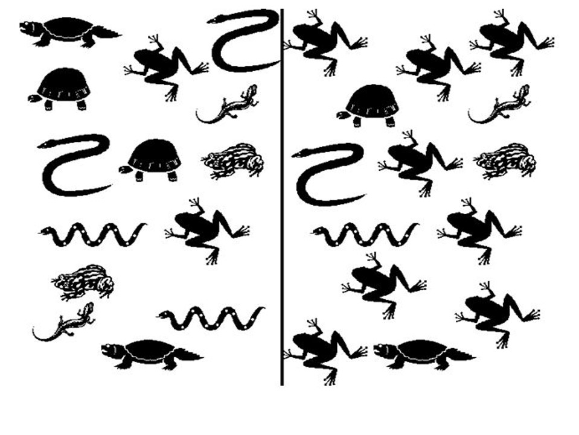

## The Selfish View: What does biodiversity provide us?

- **Moral code: Each species belongs**
  - what is the role of humans in causing, saving, or allowing extinction?
- **Practical benefits for all 3 biodiversity types**
  - genetic diversity a tool for medicines
  - diversity feeds, clothes and houses humans
- **Ecosystem Services to humans**
  - raw goods
  - health and well being
  - regulation of air, water, etc

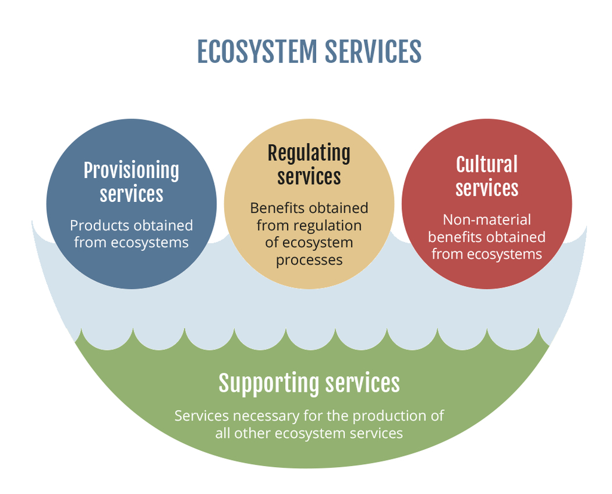

## Why is biodiversity changing?

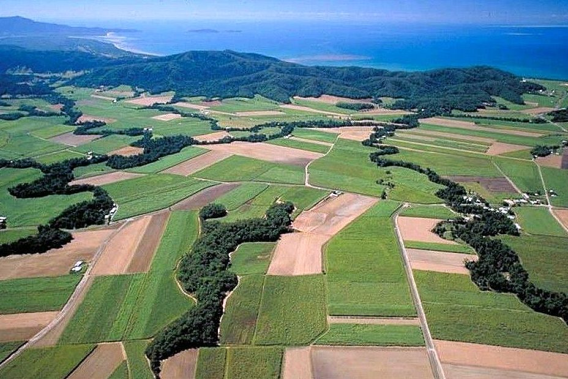

- **Human activities threaten biodiversity**
  - at each scale
- **Threats posed by humans fall into 4 categories**
1. habitat loss
2. species introductions
3. over-harvesting
4. climate change
- **Landscape change is huge threat to habitats**
  - land surfaces altered for human needs
  - causes *fragmentation* or *loss of habitat*

## Introduced species and over-harvesting

**Native vs Non-Native vs Invasive Species**

**Harvesting organisms at rates that exceed the ability of the population to recover**

**2025 Chesapeake Bay blue crab population is at the second-lowest level in the 35-year history of the Winter Survey, a 25% decrease from 2024.**

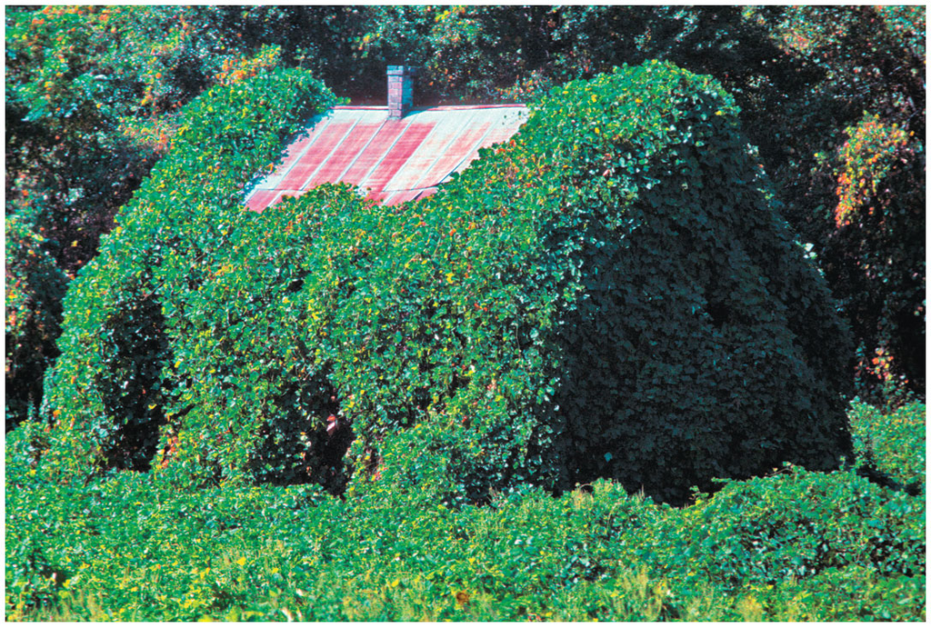

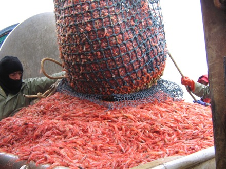

## How does conservation biology work?

**Small Population Approach - increase migration/dispersal between populations**

- **Small populations are the most vulnerable**
  - populations lose adaptive potential
- **Small populations vulnerable to inbreeding**
  - genetic issues of non-random mating
- **Small populations vulnerable to genetic drift**
  - chance loss of alleles
- **Goal: Maintain genetic diversity to avoid extinction vortex**

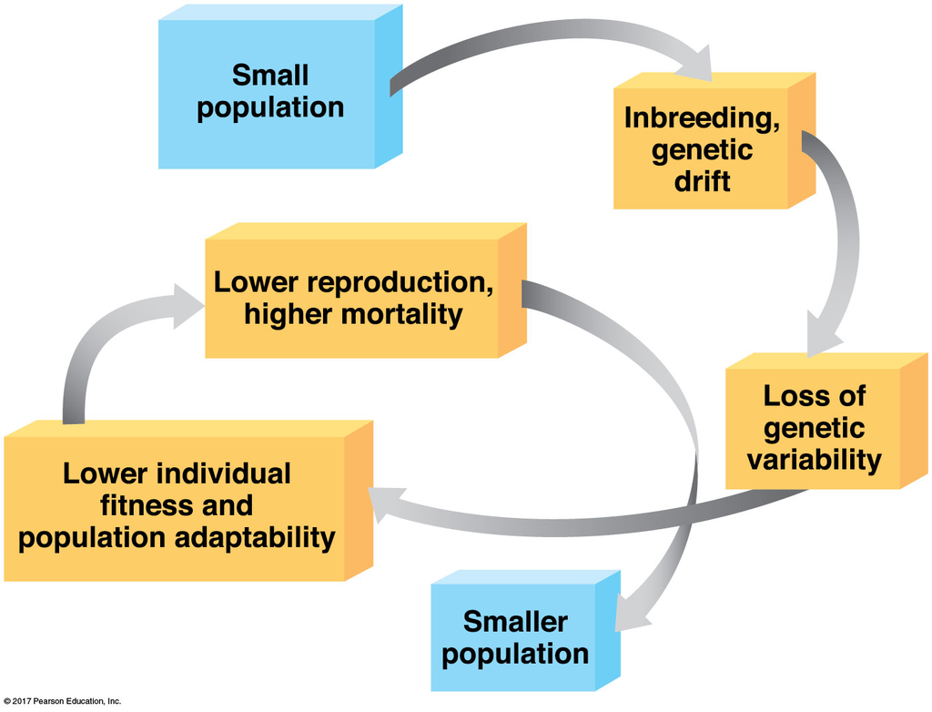

## How does conservation biology work?

**Declining Population Approach**

- **Detect downward trends in population sizes**
  - may be a large population
- **Prioritize the factors causing decline**
  - habitat loss, over-harvesting, etc.
- **What are the environmental needs of the species?**
  - What is the root cause of the decline?
  - How do we stop it?

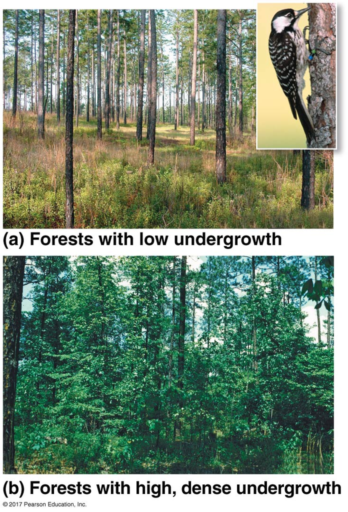

## Landscape conservation: Protecting lands / habitat corridors

**Establishing large scale protected areas via policy (terrestrial or aquatic) is first priority**  
**Habitat corridors: increase gene flow between fragmented populations**

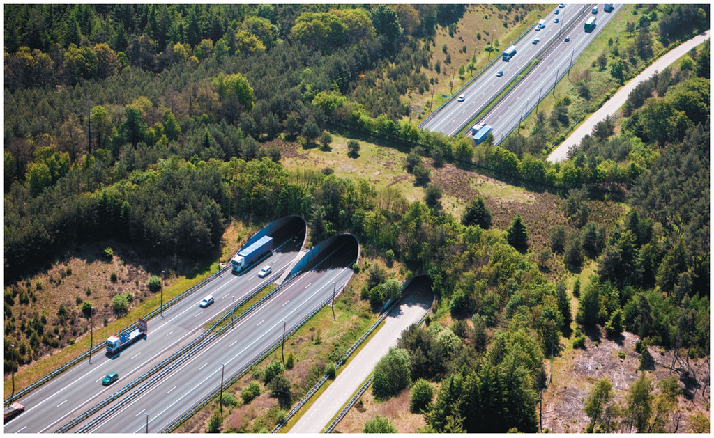

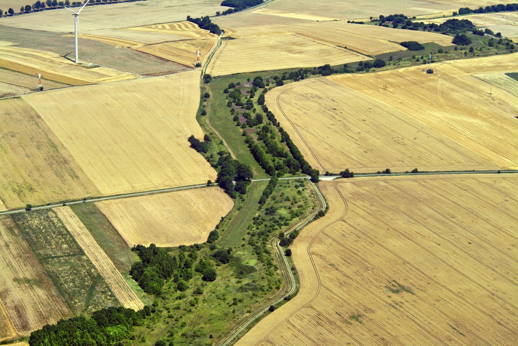

## Global Change: What is in a name?

- **Global warming:**
- **Climate change:**
  - more than just temperature
  - mostly related to post 1950’s
- **Global change:**
  - e.g. nutrient cycles, biodiversity, land use, sea level rise, ice loss + climate change

[figure not shown]

## Climate change basics

- **Climate change is strongly related to the chemistry of the atmosphere**
  - greenhouse gases absorb outgoing radiation
  - CO<sub>2</sub>, CH<sub>4</sub>, NO<sub>x</sub>, & H<sub>2</sub>O
- **Greenhouse gases intercept and absorb radiation**
  - more greenhouse gases = higher temperatures
  - enhances existing greenhouse gas effect
- **Burning of fossil fuels increases atmospheric CO<sub>2</sub>**
  - makes biosphere warmer
  - impacts weather and climate patterns

[figure not shown]

## Greenhouse effect is a natural process!

[figure not shown]

## Global Change: What can we do?

- **We likely cannot conserve all habitats**
  - which ones are the most crucial?
- **Sustainable development**
  - better engineer man-made ecosystems
  - food security while reducing environmental impacts of agriculture
  - food security while maintaining ecosystem services
- **Curb global emissions**
  - projected warming by end of century is uncertain
  - changes needed at individual, community, and policy levels

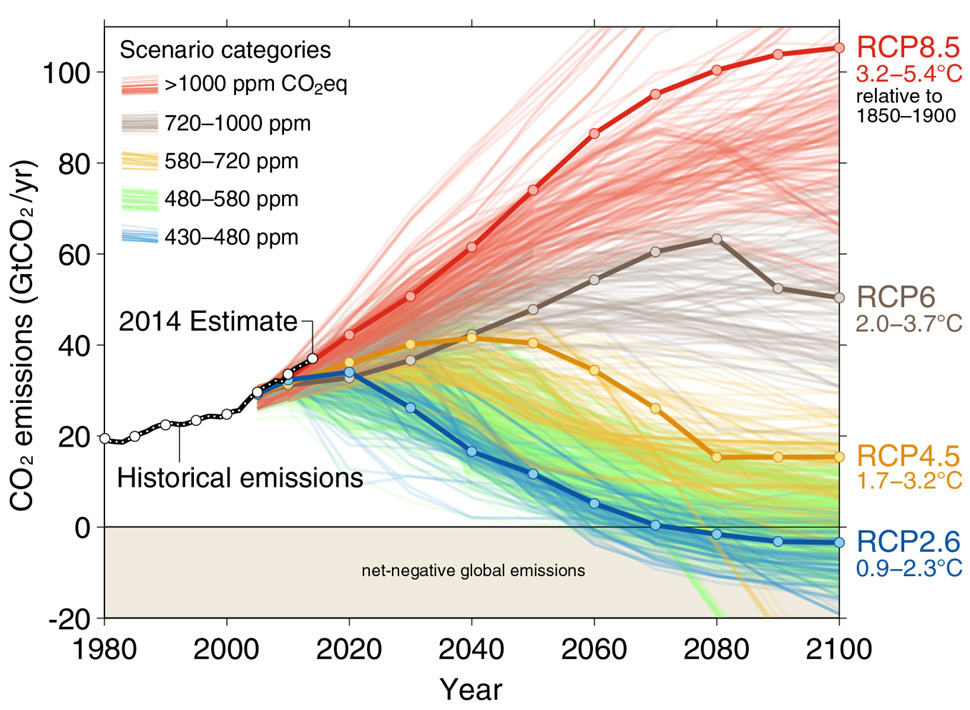

## Future of the Biosphere: New Mass Extinction?

**Present-day extinction rate is 1,000 to 10,000 times the background extinction rate because of deforestation, habitat loss, over-harvesting, pollution, climate change, and other human activities**

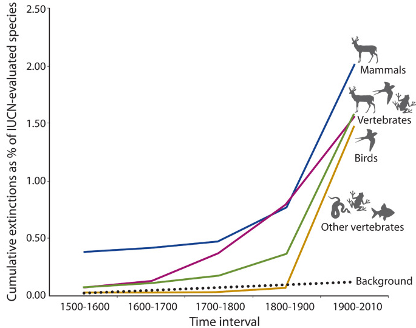

## Global change fixes are possible

**When we redesign systems — energy, food, cities, transportation, conservation — the planet responds**

**Nature-Based Solutions: Reforesting land and updating farming practices for better soil carbon storage**

**Energy transitions: rapid advancements in renewable energies are making them cheaper, more efficient, safer**

**Individual actions: Collective change in societal norms starts with individual actions**

**Your generation does not need to invent solutions. You need to improve, scale, and apply the ones we already have**